# 6.3 Market Basket Analysis

## Create some rules

- We use the Apriori algorithm in arules library to mine frequent itemsets and association rules. The algorithm employs level-wise search for frequent itemsets.
- We pass supp=0.001 and conf=0.8 to return all the rules have a support of at least 0.1% and confidence of at least 80%.
- We sort the rules by decreasing confidence.
- Have a look the summary of the rules.

```r
rules <- apriori(tr, parameter = list(supp=0.001, conf=0.8))
```

```
 Apriori

 Parameter specification:
  confidence minval smax arem  aval originalSupport maxtime support minlen
         0.8    0.1    1 none FALSE            TRUE       5   0.001      1
  maxlen target   ext
      10  rules FALSE

 Algorithmic control:
  filter tree heap memopt load sort verbose
     0.1 TRUE TRUE  FALSE TRUE    2    TRUE

 Absolute minimum support count: 19

 set item appearances ...[0 item(s)] done [0.00s].
 set transactions ...[7869 item(s), 19297 transaction(s)] done [0.72s].
 sorting and recoding items ... [2407 item(s)] done [0.03s].
 creating transaction tree ... done [0.03s].
 checking subsets of size 1 2 3 4 5 6 7 8 9 10 done [1.90s].
 writing ... [87110 rule(s)] done [0.19s].
 creating S4 object  ... done [0.17s].
```

```r
rules <- sort(rules, by='confidence', decreasing = TRUE)
summary(rules)
```

```
 set of 87110 rules

 rule length distribution (lhs + rhs):sizes
     2     3     4     5     6     7     8     9    10
   105  3133  9732 26228 29873 14020  3218   680   121

    Min. 1st Qu.  Median    Mean 3rd Qu.    Max.
   2.000   5.000   6.000   5.627   6.000  10.000

 summary of quality measures:
     support           confidence          lift             count
  Min.   :0.001036   Min.   :0.8000   Min.   :  8.781   Min.   : 20.00
  1st Qu.:0.001088   1st Qu.:0.8333   1st Qu.: 19.305   1st Qu.: 21.00
  Median :0.001192   Median :0.8750   Median : 24.786   Median : 23.00
  Mean   :0.001383   Mean   :0.8834   Mean   : 50.921   Mean   : 26.69
  3rd Qu.:0.001503   3rd Qu.:0.9231   3rd Qu.: 43.662   3rd Qu.: 29.00
  Max.   :0.018086   Max.   :1.0000   Max.   :622.484   Max.   :349.00

 mining info:
  data ntransactions support confidence
    tr         19297   0.001        0.8
```

```r
inspect(rules[1:10])
```

```
      lhs                         rhs             support     confidence
 [1]  {WOBBLY CHICKEN}         => {METAL}         0.001451003 1
 [2]  {WOBBLY CHICKEN}         => {DECORATION}    0.001451003 1
 [3]  {DECOUPAGE}              => {GREETING CARD} 0.001191895 1
 [4]  {BILLBOARD FONTS DESIGN} => {WRAP}          0.001502824 1
 [5]  {WOBBLY RABBIT}          => {METAL}         0.001761932 1
 [6]  {WOBBLY RABBIT}          => {DECORATION}    0.001761932 1
 [7]  {BLACK TEA}              => {SUGAR JARS}    0.002331969 1
 [8]  {BLACK TEA}              => {COFFEE}        0.002331969 1
 [9]  {ART LIGHTS}             => {FUNK MONKEY}   0.001969218 1
 [10] {FUNK MONKEY}            => {ART LIGHTS}    0.001969218 1
      lift      count
 [1]  385.94000 28
 [2]  385.94000 28
 [3]  344.58929 23
 [4]  622.48387 29
 [5]  385.94000 34
 [6]  385.94000 34
 [7]  212.05495 45
 [8]   61.06646 45
 [9]  507.81579 38
 [10] 507.81579 38
```

- 100% customers who bought “WOBBLY CHICKEN” end up bought “DECORATION” as well.
- 100% customers who bought “BLACK TEA” end up bought “SUGAR JAR” as well.

And plot these top 10 rules.

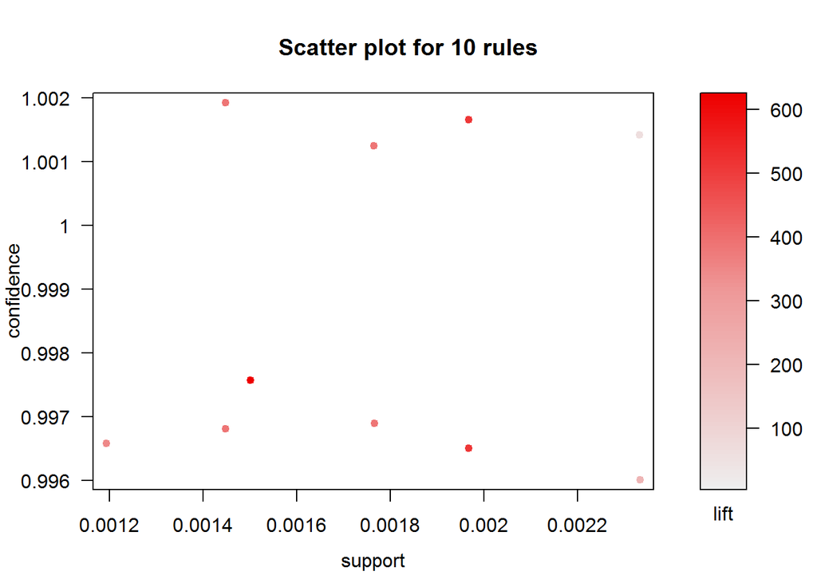

```r
topRules <- rules[1:10]
plot(topRules)
```

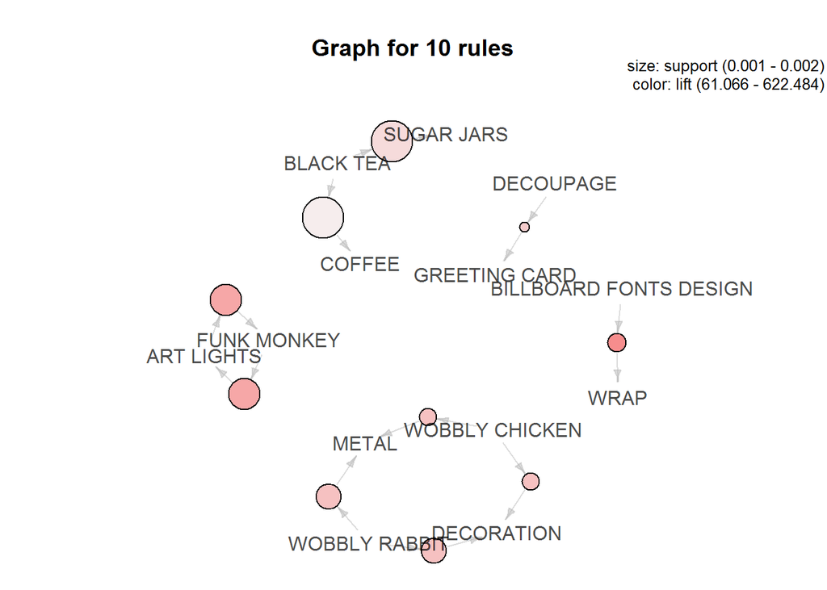

```r
plot(topRules, method="graph")
```

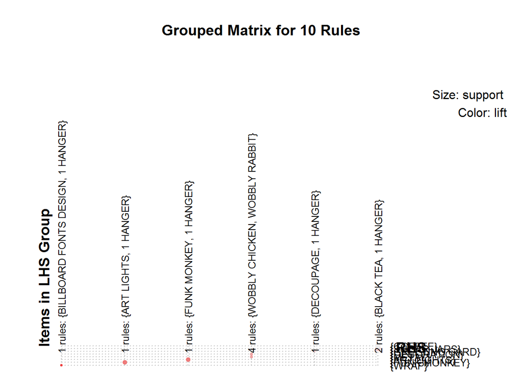

```r
plot(topRules, method = "grouped")
```

In this post, we have learned how to Perform Market Basket Analysis in R and how to interpret the results. If you want to implement them in Python, [Mlxtend](http://rasbt.github.io/mlxtend/) is a Python library that has a an implementation of the Apriori algorithm for this sort of application. You can find an introduction tutorial [here](http://pbpython.com/market-basket-analysis.html).

If you would like the R Markdown file used to make this blog post, you can find [here](https://github.com/susanli2016/Data-Analysis-with-R/blob/master/Market_Basket_Analysis.Rmd).

reference: [R and Data Mining](http://www.rdatamining.com/examples/association-rules)